# Final Project Example

2026-04-09

#### Term Project Description

This document is a final project for the UCSD Course BILD 5. My project builds upon the study referenced below. I have proposed a potential follow-up experiment to extend the study’s findings. The project utilizes simulated data, structured and analyzed as if collected from a real experiment. While the outcomes do not provide scientific evidence, they showcase my skills in formulating and addressing relevant biological questions through statistics, experimental design, and programming.

#### Article Citation

Buijze, Geert A., and Inger N. Sierevelt. “The Effect of Cold Showering on Health and Work: A Randomized Controlled Trial.” PubMed Central, 15 September 2016, https://pmc.ncbi.nlm.nih.gov/articles/PMC5025014/. Accessed 7 December 2025.

#### Research Question

How do consistent cold showers affect the cardiovascular system?

#### Null Hypothesis

Taking cold showers will have no effect on the cardiovascular system via resting heart rate. Therefore BPM Cold Shower = BPM Hot Showers

#### Alternate Hypothesis

Taking cold showers will have an effect on the cardiovascular system via resting heart rate. Therefore BPM Cold Showers =! BPM Hot Showers

#### Test Performed

Paired t-test

#### Import and Tidy the Data

```
## 'data.frame':    80 obs. of  4 variables:
##  $ X         : int  1 2 3 4 5 6 7 8 9 10 ...
##  $ ColdShower: num  49.9 72.3 104.5 108.1 63.4 ...
##  $ WarmShower: num  21.3 29.4 45.7 43.8 19.5 ...
##  $ Delta     : num  28.6 42.9 58.8 64.3 43.9 ...
```

#### Exploratory Data Analysis

In this section I would explain the things that need to be checked and how I would do so for the type of test I am performing. Before I can do a t-test, I first need to check the normality of my data that I want to be using in my t-test to see if they are in a normal distribution. Therefore, I will be building a histogram of the deltas to visualize normality then I will perform a ks test to confirm if my data follows the rules of normality.

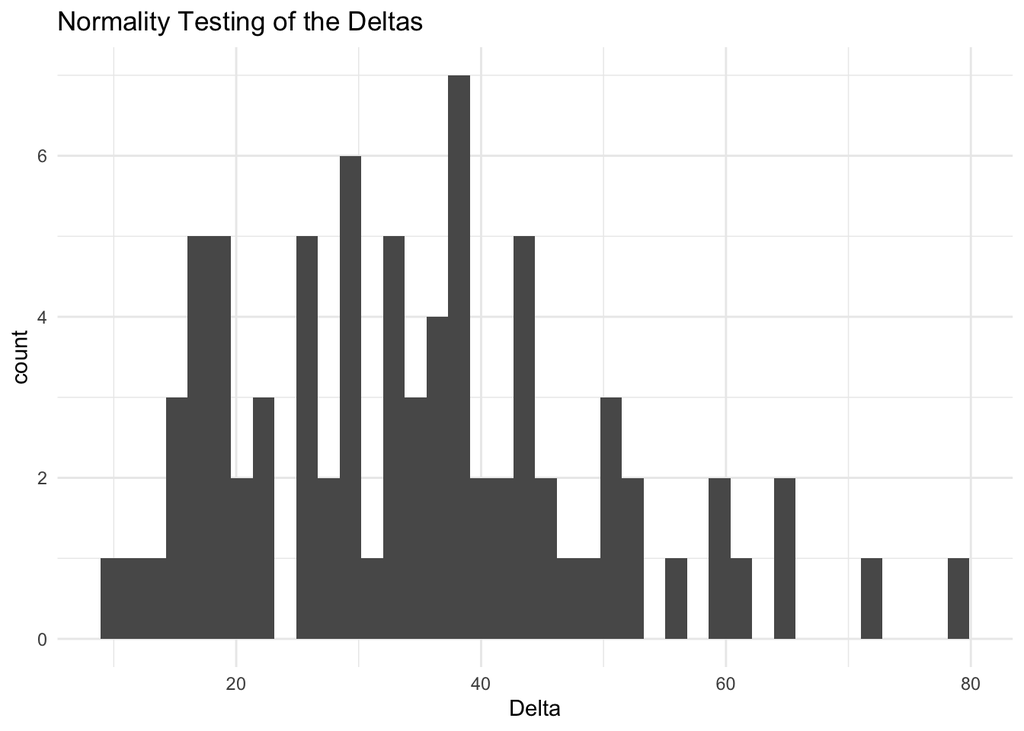

```r
ksdelta<-ks.test(TIDY_DF$Delta, pnorm, mean(TIDY_DF$Delta), sd(TIDY_DF$Delta))
ksdelta
```

```
##
##  Exact one-sample Kolmogorov-Smirnov test
##
## data:  TIDY_DF$Delta
## D = 0.065936, p-value = 0.8547
## alternative hypothesis: two-sided
```

#### Description of Current Data and Plan for Fixes if Needed

Based on the histogram graph it looks as if there might be 2 outliers on the right. However, after running a ks test, the results showed a p-value of 0.85, which is way above 0.05, therefore we accept the null of our data being drawn from a normal distribution. A transformation of data to make it conform to normality is not needed hooray! I will be continuing on with testing my null hypothesis with the same unchanged data.

#### Correct Data Issues and Build Final Data Table.

The data already meets the assumptions of the model.

```
## 'data.frame':    80 obs. of  4 variables:
##  $ X         : int  1 2 3 4 5 6 7 8 9 10 ...
##  $ ColdShower: num  49.9 72.3 104.5 108.1 63.4 ...
##  $ WarmShower: num  21.3 29.4 45.7 43.8 19.5 ...
##  $ Delta     : num  28.6 42.9 58.8 64.3 43.9 ...
```

#### Test the Null Hypothesis of Your Research Question

```r
#Since I am running a paired t-test I don't need the ~ so will be running a one sample t test function for the deltas
ttestresult<-t.test(Corrected_TIDY_DF$Delta)
ttestresult
```

```
##
##  One Sample t-test
##
## data:  Corrected_TIDY_DF$Delta
## t = 21.003, df = 79, p-value < 2.2e-16
## alternative hypothesis: true mean is not equal to 0
## 95 percent confidence interval:
##  31.37814 37.94829
## sample estimates:
## mean of x
##  34.66321
```

```r
#Okay our null statement is that the difference between the before and after is equal to 0. That means that they are the same and there is no difference. Because the p-value is very low, way lower than 0.05 then that means that we reject the null hypothesis and say that it is more probable to say that there is a difference than there isn't.
```

#### Build the Figure That Best Tells the Story of Your Model

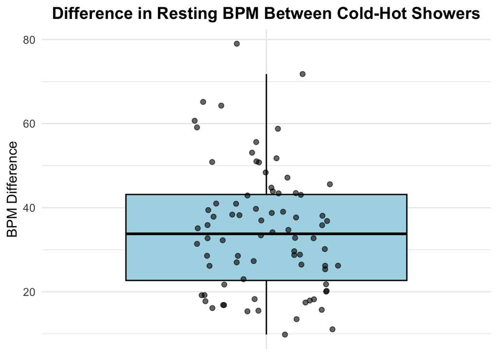

#### Figure Caption

Our p-value based on the paired t-test is 2.2e-16 which is less than our alpha value of 0.05. We reject the null hypothesis that being there is no difference in the means resting heart rate in BPM between cold showers and hot showers. This means that the difference between the two means is not 0. The t-score is 21.003 and our degrees of freedom is 79. Although we aren’t sure the exact value of the difference, there is a 95% confidence interval that the true difference of the means is between 31.37814 BPM and 37.94829 BPM.

Although the data is hypothetical, we continue on the ideas and questions provided by the cited source with researching cold shower effects on the cardiovascular system, notably resting heart rate because it mentions how both cold showers and engaging in regular physical activity resulted in a reduction of sick days. I wondered if it could be related to the cardiovascular system as engaging in physical activity reduces resting heart rate and if taking cold showers would do the same. Based on the imaginary data, it shows that taking cold showers does change the heart rate of individuals although it seems to raise the heart rate instead of reducing it based on the data given.

AI Citation: OpenAI. (2025). ChatGPT Version GPT-5.1 model https://chat.openai.com/chat. Prompts: [picture] How should I recode this to make the graph more visually appealling, How do I remove x axis numbers from the graph and add colors, If I want to add geom point and have points vary throughout graph how do I do that.

Response: I copy and pasted its improved version over the drafted version I had earlier so its response is the code I used to create the graph.